# Estudio variabilidad estructural proteica

## Conjuntos de proteinas

### Conjunto teorico

160 mutantes de 1hmt (131 sitios) simuladas con el modelo mutacional LFENM con ANM *R0* = 12 y *Fmax* = 2 (solo para LFENM).

Con seleccion natural (ns = T): para determinar que sitios mutar, se alineo 1hmt con cada una de las proteinas del conjunto, se obtuvieron los indices de los sitios alineados pero mutados y de los sitios con gaps y se simularon 10 mutantes por cada par de proteinas, obteniendose un total de 160 mutantes. Luego, para el analisis, se tomaron como alineados los sitios alineados de 1hmt para cada par de proteinas.

Sin seleccion natural (ns = F): se mutaron al azar la cantidad de sitios correspondientes al % id del conjunto experimental y luego, para el analisis, se tomaron como alineados todos los sitios.

### Conjunto experimental

16 proteinas de la familia de fabp. Las proteinas tienen un promedio de identidad secuencial de 45%. El core del alineamiento de la familia es de 122 sitios.

### Analisis

Se realizaron 2 tipos de analisis:

*Core (C = T)*: se analizo solo el core conservado del alinemiento (sitios sin gaps en el alineamiento multiple).

*No Core (C = F)*: no se utilizo el core para el analisis.

La caracterizacion del conjunto experimental se muestra a continuacion:

```
##    pdbid nsites naligned identity       MSD
## 1   1lif    131      131 64.12214 0.5140829
## 2  1pmpa    131      131 60.30534 0.2951834
## 3  1fdqa    131      131 66.41221 0.7106845
## 4  1opba    133      130 40.76923 2.2275226
## 5  1ggla    134      130 35.38462 2.2520478
## 6   1cbs    137      130 43.84615 3.6170725
## 7  1cbia    136      130 42.30769 5.7580068
## 8  1ftpa    133      130 43.07692 2.5343553
## 9  1eioa    127      125 27.20000 3.4827396
## 10 3ifba    131      129 33.33333 4.2618441
## 11  1b56    133      131 49.61832 0.8192630
## 12 1bwya    132      131 88.54962 2.2788140
## 13  1crb    134      130 32.30769 2.0210579
## 14  1mdc    131      127 33.07087 4.4809130
## 15  1lfo    126      125 26.40000 2.9332803
## 16  1ifc    131      129 32.55814 2.0268097
```

## Comparaciones

### MSD

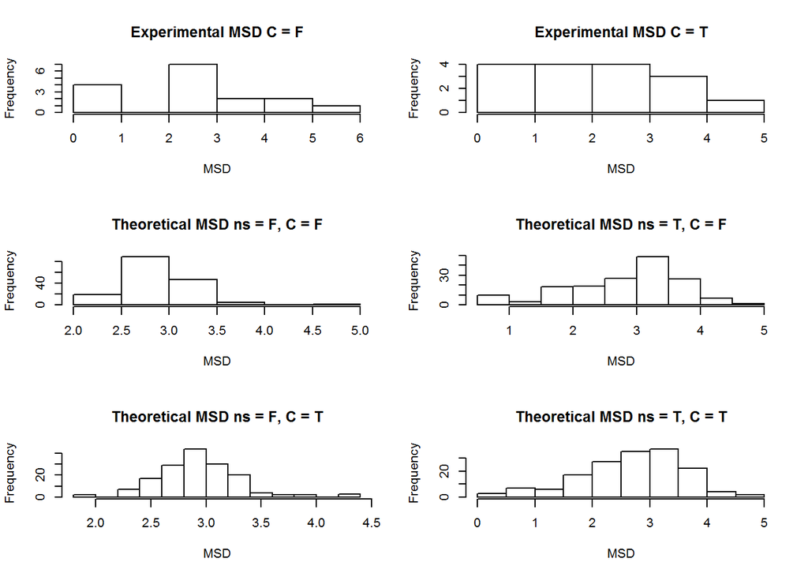

### MSDi

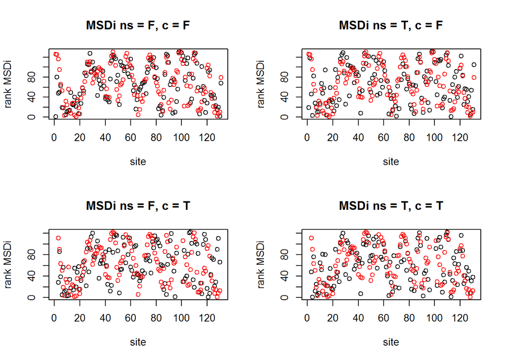

rojo: experimental negro: teorico

Los perfiles de MSDi fueron normalizados con la funcion rank().

### RHO y AUC

Las distribuciones de *auc* y *rho* para cada conjunto se muestran a continuacion (negro = teorico, rojo = experimental)

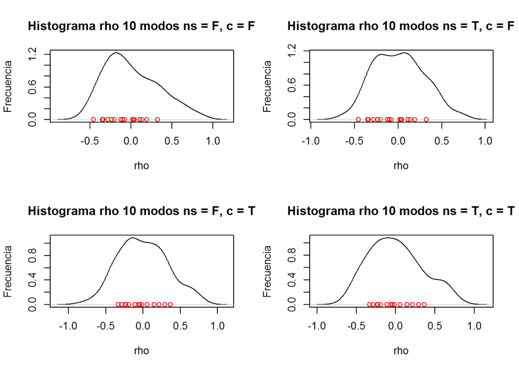

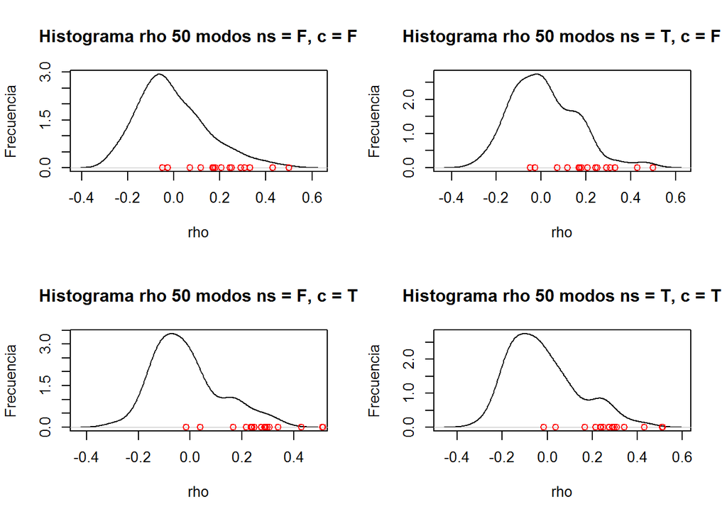

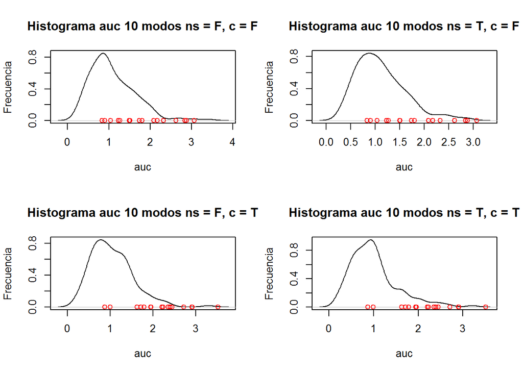

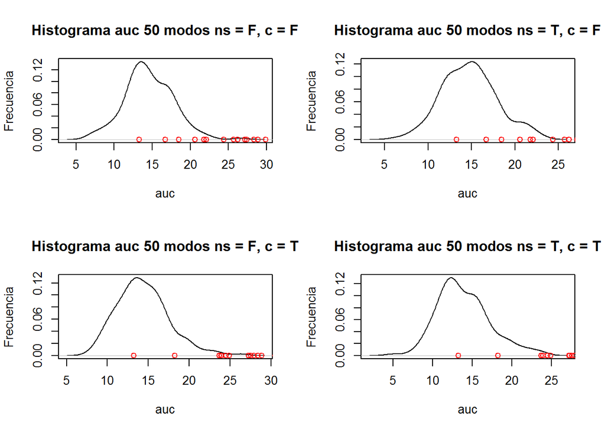

## Pn y Qn

Las distribuciones de *Pn* y *Qn* de los conjuntos son las siguientes:

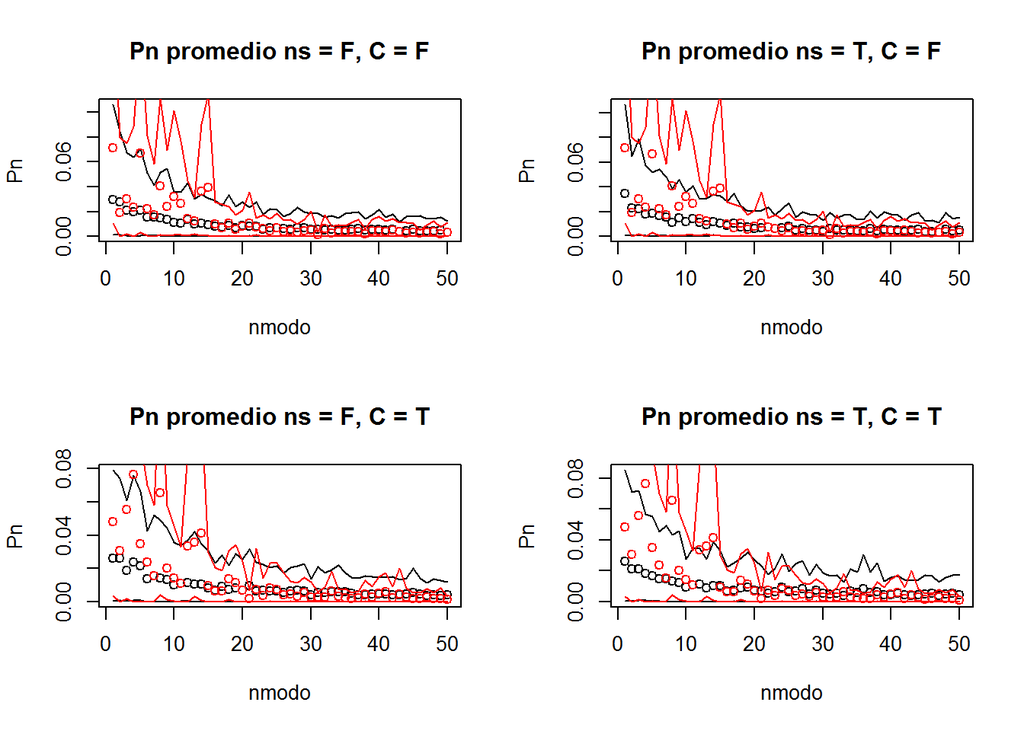

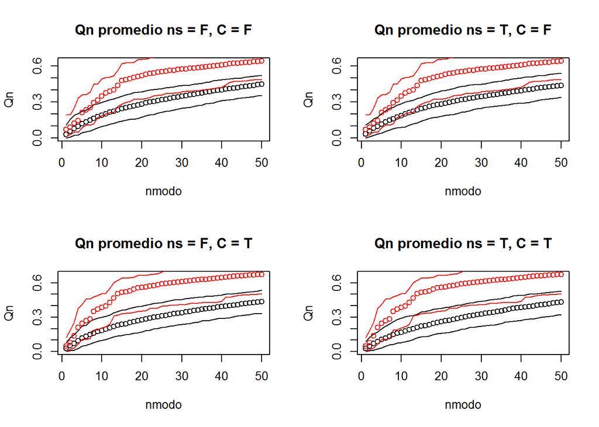

*Negro*: Puntos: promedio de promedios teorico. Lineas: promedio de cuantiles 0.05 y 0.95 de 10 grupos de 16 mutantes teoricas. *Rojo*: Experimental. Puntos: promedio. Lineas: cuantiles 0.05 y 0.95.

## R^2 y MSE

Las comparaciones entre perfines promedio Pn y MSDi teoricos fiteados y experimentales se muestran a continuacion. En cada grafico se muestra la correlacion (R^2) y el error (MSE).

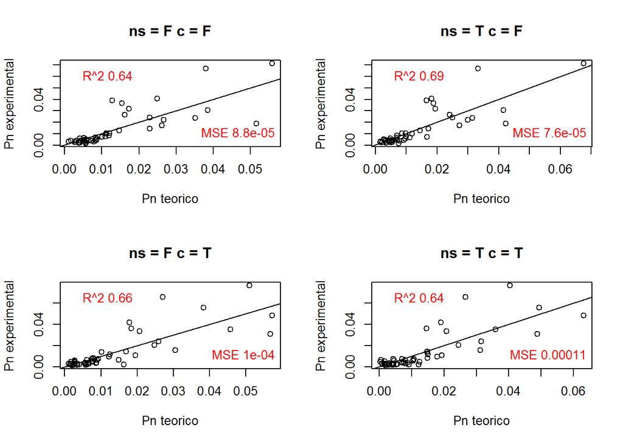

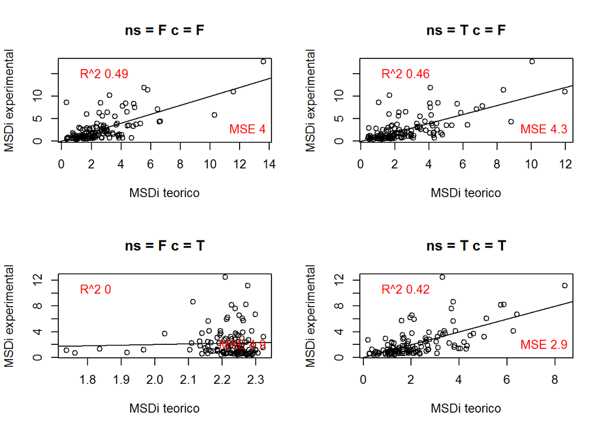